# Introduction

Thomas Manke

5 Dec 2016

# Overview of R-course

## Day 1: Groundwork

- Intro to RStudio: a GUI for R
- The Basics: data types and classes
- function structures (understanding output)
- summarizing data: descriptive statistics
- simple plotting and correlation analysis

## Day 2: Visualization, Statistics and Scripts

- getting data in and out
- advanced visualization: heatmaps
- case studies and some statistics
- programming simple scripts

## Day 3: Open the universe

- installing and using packages
- manipulating data: cleaning, filtering, merging
- from interactive use to scripting

# Goals:

After the course you will be able to

- understand the basic syntax of R
- find help for more nifty problems
- install and use packages for your specific questions
- see the limitations of EXCEL
- understand the importance of structured data
- understand some bioinformatics jargon
- understand common difficulties in data analysis
- increase the value of your CV
- produce figures such as

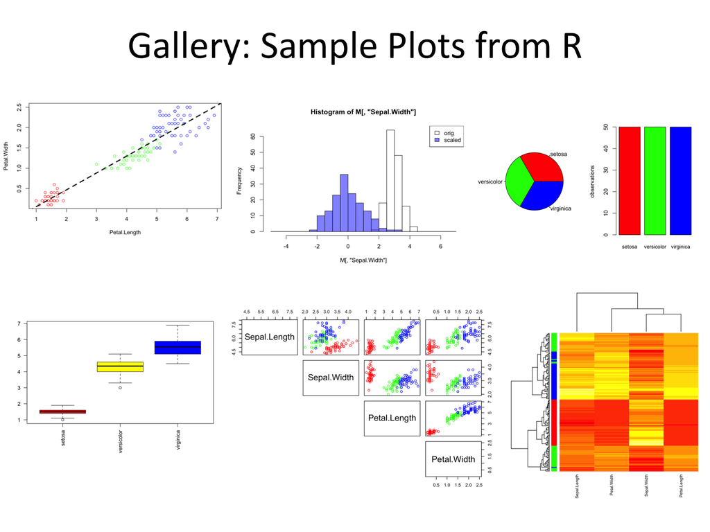

Typical examples from R.

# Non-Goals:

This course does *not* teach

- programming new tools: focus on existing tools
- bioinformatics: BSc course (3 yrs ++)
- NGS analysis: other programs (Linux, Galaxy, deepTools)

# Why R ?

- Standard software for data analysis, statistics, and visualization
- free and community support
- many packages available (for data I/O, manipulation, high-end: expression analysis)
- good compromise between flexibility (programming) and box-solutions (packages)
- suitable for very large dataset (filtering, merging)
- interactive and scripting
- not the best solution for everything (e.g. mapping)
- frequent requirement during (bioinformatics) hiring

# First hurdles

- its a new language: vocabulary & grammar
- computers are stuborn and stupid: they do not think along
- case sensitivity: $a \ne A$
- choices: many ways to say (to program) things
- more choices: 3000 (redundant) packages
- learning curve: steep (but rewarding)